# Red de Empresas

### Arboretum de Estancia La Constancia

Un espacio donde las empresas trascienden, generando impacto real en naturaleza, comunidad y bienestar.

La Red de Empresas del Jardín Botánico de Mar del Plata invita a organizaciones visionarias a formar parte de un proyecto único que integra naturaleza, bienestar, educación y comunidad.

Sumarse es contribuir a la construcción de un legado que trasciende generaciones, impulsando la conservación ambiental y creando un espacio donde empresas, personas y naturaleza crecen juntas.

## La Red de Empresas

**🌿 ¿Por qué sumarte?**

- Formar parte del primer Jardín Botánico de Mar del Plata, un espacio donde naturaleza, comunidad y empresas generan impacto real.
- Asociar tu organización a valores de sostenibilidad, innovación y futuro.
- Integrarte a una red empresarial con propósito.

**📊 Beneficios**

- Presencia en redes sociales y materiales institucionales.
- Networking empresarial.
- Encuentros sobre sostenibilidad y triple impacto.
- Actividades de bienestar en la naturaleza.
- Jornadas de voluntariado corporativo.

**🥾 Cómo participar**

- Sponsoreo de proyectos del Jardín Botánico.
- Aportes en especie o colaboración institucional.

## Proyectos

- 🌿 Señalética educativa
- 🌿 Senderos interpretativos
- 🌿 Bancos y espacios de descanso
- 🌿 Identificación de especies
- 🌿 Baños ecológicos e inclusivos

## **Coordinación de la Red de Empresas**

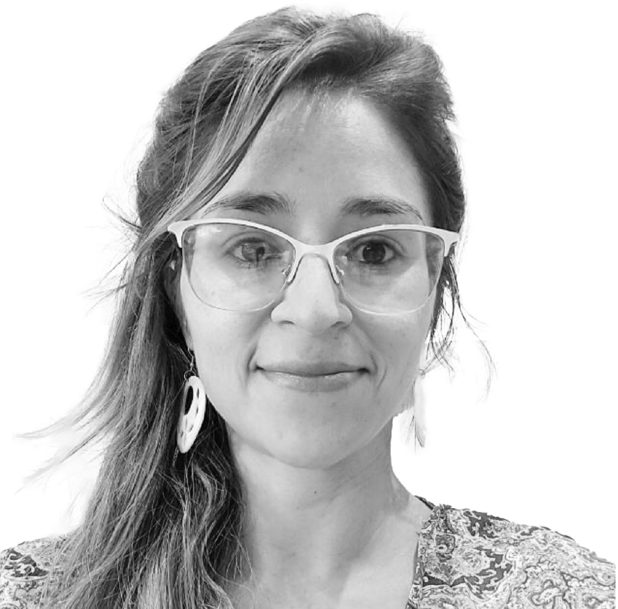

### Magdalena

🔗 [LinkedIn](https://www.linkedin.com/in/magdalenazurita/?locale=en)

Responsable de la coordinación institucional, programas educativos y conservación.

[figure not shown]

### Juan Ignacio

🔗 [LinkedIn](https://www.linkedin.com/in/juan-ignacio-z-4b345425/)

Responsable del desarrollo estratégico, vinculación con empresas y comunicación institucional.

## Cómo sumarte a la Red

Completa el formulario expresando tu interés y nuestro equipo se pondrá en contacto contigo.

## Empresas Fundadoras de la Red

[figure not shown]

## Contacto y Ubicación

**Correo:** laconstanciaargentina@gmail.com

📍 Ubicación  
Arboretum de Estancia La Constancia  
Camino 515, Mar del Plata, Argentina

[📍 Abrir en Google Maps](https://maps.app.goo.gl/jQaTGHeaecL4icSg9)